# Storm Events Database

The purpose of this Jupyter Notebook is to demonstrate how to read the .csv files from the SPC Storm Events Database.

## Where did the data come from?

The data were downloaded from the NOAA National Center for Environmental Information.  
Details about the database and the data files are available here: https://www.ncdc.noaa.gov/stormevents/details.jsp

## Where is the data located on SoM Computers?

The data are located in: */data/esplab/shared/classes/metr3334/class_data/stormevents/*

## What Files are there?

- StormEvents_details*.csv
- StormEvents_fatalities*.csv
- StormEvents_locations*.csv
- stormdata_*.csv

## How do I understand what is in each file?

- Storm-Data-Bulk-csv-Format.pdf
- Storm-Data-Export-Format.pdf

```python
# Imports
import numpy as np
```

```python
# Filename
fname='/data/esplab/shared/classes/metr3334/class_data/stormevents/StormEvents_details-ftp_v1.0_d2019_c20230118.csv'
```

```python
# Read in the data using numpy loadtxt
storm_data=np.loadtxt(fname, delimiter=',')
```

[output not shown]

## Why doesn't numpy work?

`numpy` requires all data to be integers or floats in a `numpy.ndarray`. A string was found in the data.

## What do we do now?

We will use a python package called [`pandas`](https://pandas.pydata.org/) that is designed for working with tabular data with mixed data types. Let's try importing it.

```python
import pandas as pd
```

```python
storm_df=pd.read_csv(fname)
```

```python
storm_df
```

|  | BEGIN_YEARMONTH | BEGIN_DAY | BEGIN_TIME | END_YEARMONTH | END_DAY | END_TIME | EPISODE_ID | EVENT_ID | STATE | STATE_FIPS | ... | END_RANGE | END_AZIMUTH | END_LOCATION | BEGIN_LAT | BEGIN_LON | END_LAT | END_LON | EPISODE_NARRATIVE | EVENT_NARRATIVE | DATA_SOURCE |
| --- | --- | --- | --- | --- | --- | --- | --- | --- | --- | --- | --- | --- | --- | --- | --- | --- | --- | --- | --- | --- | --- |
| 0 | 201905 | 9 | 1554 | 201905 | 9 | 1830 | 137295 | 824116 | TEXAS | 48 | ... | 7.0 | NNE | SAN GERONIMO | 29.7898 | -98.6406 | 29.7158 | -98.7744 | Thunderstorms developed along a cold front as ... | Thunderstorms produced heavy rain that led to ... | CSV |
| 1 | 201908 | 1 | 0 | 201908 | 7 | 1400 | 141502 | 849617 | SOUTH DAKOTA | 46 | ... | 3.0 | W | BRUCE | 44.5400 | -96.9600 | 44.4300 | -96.9400 | Minor flooding slowly dwindled during early Au... | A continuation of flooding from July, the Big ... | CSV |
| 2 | 201902 | 19 | 2226 | 201902 | 19 | 2350 | 134941 | 808922 | ARKANSAS | 5 | ... | NaN | NaN | NaN | NaN | NaN | NaN | NaN | Rain was heavy at times on the 19th, and there... | One-quarter inch of freezing rain was measured... | CSV |
| 3 | 201902 | 19 | 2255 | 201902 | 19 | 2355 | 134941 | 808923 | ARKANSAS | 5 | ... | NaN | NaN | NaN | NaN | NaN | NaN | NaN | Rain was heavy at times on the 19th, and there... | One-quarter inch of freezing rain was measured... | CSV |
| 4 | 201901 | 29 | 1200 | 201901 | 29 | 1900 | 133946 | 801726 | WEST VIRGINIA | 54 | ... | NaN | NaN | NaN | NaN | NaN | NaN | NaN | A strong surface cold front crossed the region... | Snowfall amounts of 1 to 2 inches were observe... | CSV |
| ... | ... | ... | ... | ... | ... | ... | ... | ... | ... | ... | ... | ... | ... | ... | ... | ... | ... | ... | ... | ... | ... |
| 67854 | 201908 | 23 | 1809 | 201908 | 23 | 1817 | 141859 | 851546 | ARIZONA | 4 | ... | 6.0 | WNW | (FHU)FT HUACHUCA AFB | 31.5920 | -110.3288 | 31.6055 | -110.4456 | Scattered thunderstorms formed over a large pa... | KFHU and KALK ASOS weather stations measured t... | CSV |
| 67855 | 201908 | 28 | 1700 | 201908 | 28 | 1733 | 141860 | 851549 | ARIZONA | 4 | ... | 2.0 | WNW | (DMA)DAVIS MONTHAN A | 32.2500 | -110.8236 | 32.1755 | -110.9109 | Widespread thunderstorms formed during the aft... | Trees were downed and uprooted at Ajo and Alve... | CSV |
| 67856 | 201908 | 28 | 1745 | 201908 | 28 | 1745 | 141860 | 851550 | ARIZONA | 4 | ... | 1.0 | W | VAIVO VO | 32.7200 | -111.9300 | 32.7200 | -111.9300 | Widespread thunderstorms formed during the aft... | Five power poles were downed north of Via Vo F... | CSV |
| 67857 | 201908 | 28 | 1830 | 201908 | 28 | 1830 | 141860 | 851551 | ARIZONA | 4 | ... | 13.0 | N | COPPER CREEK | 32.9400 | -110.4900 | 32.9400 | -110.4900 | Widespread thunderstorms formed during the aft... | Horse Camp RAWS recorded wind gust of 61 mph. | CSV |
| 67858 | 201908 | 28 | 1639 | 201908 | 28 | 1639 | 141860 | 851864 | ARIZONA | 4 | ... | 6.0 | SSW | VAIL JCT | 31.9500 | -110.7700 | 31.9500 | -110.7700 | Widespread thunderstorms formed during the aft... | Penny sized hail was reported south of Vail. | CSV |

67859 rows × 51 columns

## Pandas `DataFrame`

In `pandas`, storm_df is called a `DataFrame`. This is its data type.

```python
type(storm_df)
```

```
pandas.core.frame.DataFrame
```

### It contains columns and rows just like a table

```python
#We can see what all the available columns are
storm_df.columns
```

```
Index(['BEGIN_YEARMONTH', 'BEGIN_DAY', 'BEGIN_TIME', 'END_YEARMONTH',
       'END_DAY', 'END_TIME', 'EPISODE_ID', 'EVENT_ID', 'STATE', 'STATE_FIPS',
       'YEAR', 'MONTH_NAME', 'EVENT_TYPE', 'CZ_TYPE', 'CZ_FIPS', 'CZ_NAME',
       'WFO', 'BEGIN_DATE_TIME', 'CZ_TIMEZONE', 'END_DATE_TIME',
       'INJURIES_DIRECT', 'INJURIES_INDIRECT', 'DEATHS_DIRECT',
       'DEATHS_INDIRECT', 'DAMAGE_PROPERTY', 'DAMAGE_CROPS', 'SOURCE',
       'MAGNITUDE', 'MAGNITUDE_TYPE', 'FLOOD_CAUSE', 'CATEGORY', 'TOR_F_SCALE',
       'TOR_LENGTH', 'TOR_WIDTH', 'TOR_OTHER_WFO', 'TOR_OTHER_CZ_STATE',
       'TOR_OTHER_CZ_FIPS', 'TOR_OTHER_CZ_NAME', 'BEGIN_RANGE',
       'BEGIN_AZIMUTH', 'BEGIN_LOCATION', 'END_RANGE', 'END_AZIMUTH',
       'END_LOCATION', 'BEGIN_LAT', 'BEGIN_LON', 'END_LAT', 'END_LON',
       'EPISODE_NARRATIVE', 'EVENT_NARRATIVE', 'DATA_SOURCE'],
      dtype='object')
```

### What can we do with a `DataFrame`?

We can select based on columns using the `loc` function available in pandas

For example, suppose we wanted to select all rows in which there was a storm in Oklahoma.

```python
ok_storms=storm_df.loc[storm_df['STATE'] == 'OKLAHOMA']
```

```python
ok_storms
```

|  | BEGIN_YEARMONTH | BEGIN_DAY | BEGIN_TIME | END_YEARMONTH | END_DAY | END_TIME | EPISODE_ID | EVENT_ID | STATE | STATE_FIPS | ... | END_RANGE | END_AZIMUTH | END_LOCATION | BEGIN_LAT | BEGIN_LON | END_LAT | END_LON | EPISODE_NARRATIVE | EVENT_NARRATIVE | DATA_SOURCE |
| --- | --- | --- | --- | --- | --- | --- | --- | --- | --- | --- | --- | --- | --- | --- | --- | --- | --- | --- | --- | --- | --- |
| 986 | 201905 | 5 | 1523 | 201905 | 5 | 1523 | 137482 | 825695 | OKLAHOMA | 40 | ... | 10.0 | SW | GRIGGS | 36.5100 | -102.2500 | 36.510 | -102.2500 | A weak disturbance in broad west northwest flo... | NaN | CSV |
| 3015 | 201906 | 1 | 1228 | 201906 | 1 | 1228 | 138310 | 832406 | OKLAHOMA | 40 | ... | 1.0 | ESE | WARR ACRES | 35.5100 | -97.6000 | 35.510 | -97.6000 | A small line of thunderstorms produced isolate... | Reported from Twitter. | CSV |
| 3016 | 201906 | 1 | 1248 | 201906 | 1 | 1248 | 138310 | 832407 | OKLAHOMA | 40 | ... | 1.0 | E | MUSTANG | 35.3900 | -97.7100 | 35.390 | -97.7100 | A small line of thunderstorms produced isolate... | Report relayed through nwschat. | CSV |
| 3017 | 201906 | 1 | 1313 | 201906 | 1 | 1313 | 138310 | 832410 | OKLAHOMA | 40 | ... | 0.0 | NNW | DEL CITY | 35.4560 | -97.4436 | 35.456 | -97.4436 | A small line of thunderstorms produced isolate... | Large tree fell on house at 4100 block of SE 9... | CSV |
| 3152 | 201906 | 4 | 319 | 201906 | 4 | 319 | 138479 | 832626 | OKLAHOMA | 40 | ... | 1.0 | ENE | OKARCHE | 35.7400 | -97.9600 | 35.740 | -97.9600 | Thunderstorms produced isolated severe hail an... | Text communication with a measurement. | CSV |
| ... | ... | ... | ... | ... | ... | ... | ... | ... | ... | ... | ... | ... | ... | ... | ... | ... | ... | ... | ... | ... | ... |
| 66214 | 201908 | 26 | 2030 | 201908 | 26 | 2030 | 141581 | 851386 | OKLAHOMA | 40 | ... | 1.0 | NW | OKLAHOMA CITY | 35.4800 | -97.5200 | 35.480 | -97.5200 | A highly unstable airmass and a cold front pro... | Car window impaled by tree branch roughly 2 in... | CSV |
| 66215 | 201908 | 26 | 2020 | 201908 | 26 | 2020 | 141581 | 851384 | OKLAHOMA | 40 | ... | 1.0 | E | (PWA)WILEY POST APT | 35.5300 | -97.6400 | 35.530 | -97.6400 | A highly unstable airmass and a cold front pro... | ASOS measured report. | CSV |
| 66260 | 201902 | 23 | 401 | 201902 | 23 | 1800 | 134811 | 808020 | OKLAHOMA | 40 | ... | NaN | NaN | NaN | NaN | NaN | NaN | NaN | A surface quickly moving northeast through the... | Estimated 2 of snow with blizzard condition si... | CSV |
| 66967 | 201904 | 30 | 2007 | 201904 | 30 | 2026 | 136286 | 822242 | OKLAHOMA | 40 | ... | 11.0 | NNE | BOKCHITO | 33.9711 | -96.2071 | 34.157 | -96.0586 | A stationary front and and upper wave produced... | A tornado developed about 2 miles south-southe... | CSV |
| 66998 | 201904 | 30 | 2026 | 201904 | 30 | 2042 | 136286 | 822281 | OKLAHOMA | 40 | ... | 2.0 | NE | LANE | 34.1570 | -96.0586 | 34.319 | -95.9740 | A stationary front and and upper wave produced... | This tornado initially developed in Bryan Coun... | CSV |

1802 rows × 51 columns

### Suppose we only care about storm events in Oklahoma that involved deaths caused by tornadoes

One of our columns is `EVENT TYPE`, so we will choose tornadoes. One of our columns is `DEATHS_DIRECT`, so we will choose >0.

```python
ok_tornados_deaths=ok_storms.loc[(ok_storms['EVENT_TYPE'] == 'Tornado') & (ok_storms['DEATHS_DIRECT'] >0)]
```

```python
ok_tornados_deaths
```

|  | BEGIN_YEARMONTH | BEGIN_DAY | BEGIN_TIME | END_YEARMONTH | END_DAY | END_TIME | EPISODE_ID | EVENT_ID | STATE | STATE_FIPS | ... | END_RANGE | END_AZIMUTH | END_LOCATION | BEGIN_LAT | BEGIN_LON | END_LAT | END_LON | EPISODE_NARRATIVE | EVENT_NARRATIVE | DATA_SOURCE |
| --- | --- | --- | --- | --- | --- | --- | --- | --- | --- | --- | --- | --- | --- | --- | --- | --- | --- | --- | --- | --- | --- |
| 54623 | 201905 | 25 | 2128 | 201905 | 25 | 2132 | 137035 | 830307 | OKLAHOMA | 40 | ... | 3.0 | ESE | EL RENO | 35.5000 | -97.9550 | 35.510 | -97.9190 | Scattered supercells merged into a linear syst... | An intense QLCS tornado developed south of El ... | CSV |
| 66967 | 201904 | 30 | 2007 | 201904 | 30 | 2026 | 136286 | 822242 | OKLAHOMA | 40 | ... | 11.0 | NNE | BOKCHITO | 33.9711 | -96.2071 | 34.157 | -96.0586 | A stationary front and and upper wave produced... | A tornado developed about 2 miles south-southe... | CSV |

2 rows × 51 columns

### Suppose we only want a count of how many tornados caused deaths in Oklahoma

```python
len(ok_tornados_deaths)
```

```
2
```

### What if we wanted to know the total number of deaths caused by tornadoes in Oklahoma

```python
ok_tornados_deaths['DEATHS_DIRECT'].sum()
```

```
4
```

# Challenges

### Remember that we only opened one file for 2019

How could we open all the files to get this information for all years?

```python
import glob
```

```python
fnames=glob.glob('/data/esplab/shared/classes/metr3334/class_data/stormevents/StormEvents_details-ftp_v1.0_d*_*.csv')
```

```python
fnames
```

```
['/data/esplab/shared/classes/metr3334/class_data/stormevents/StormEvents_details-ftp_v1.0_d1951_c20210803.csv',
 '/data/esplab/shared/classes/metr3334/class_data/stormevents/StormEvents_details-ftp_v1.0_d1952_c20210803.csv',
 '/data/esplab/shared/classes/metr3334/class_data/stormevents/StormEvents_details-ftp_v1.0_d1953_c20210803.csv',
 '/data/esplab/shared/classes/metr3334/class_data/stormevents/StormEvents_details-ftp_v1.0_d1954_c20210803.csv',
 '/data/esplab/shared/classes/metr3334/class_data/stormevents/StormEvents_details-ftp_v1.0_d1955_c20210803.csv',
 '/data/esplab/shared/classes/metr3334/class_data/stormevents/StormEvents_details-ftp_v1.0_d1956_c20210803.csv',
 '/data/esplab/shared/classes/metr3334/class_data/stormevents/StormEvents_details-ftp_v1.0_d1957_c20210803.csv',
 '/data/esplab/shared/classes/metr3334/class_data/stormevents/StormEvents_details-ftp_v1.0_d1958_c20210803.csv',
 '/data/esplab/shared/classes/metr3334/class_data/stormevents/StormEvents_details-ftp_v1.0_d1959_c20210803.csv',
 '/data/esplab/shared/classes/metr3334/class_data/stormevents/StormEvents_details-ftp_v1.0_d1960_c20210803.csv',
 '/data/esplab/shared/classes/metr3334/class_data/stormevents/StormEvents_details-ftp_v1.0_d1961_c20210803.csv',
 '/data/esplab/shared/classes/metr3334/class_data/stormevents/StormEvents_details-ftp_v1.0_d1962_c20210803.csv',
 '/data/esplab/shared/classes/metr3334/class_data/stormevents/StormEvents_details-ftp_v1.0_d1963_c20210803.csv',
 '/data/esplab/shared/classes/metr3334/class_data/stormevents/StormEvents_details-ftp_v1.0_d1964_c20210803.csv',
 '/data/esplab/shared/classes/metr3334/class_data/stormevents/StormEvents_details-ftp_v1.0_d1965_c20210803.csv',
 '/data/esplab/shared/classes/metr3334/class_data/stormevents/StormEvents_details-ftp_v1.0_d1966_c20210803.csv',
 '/data/esplab/shared/classes/metr3334/class_data/stormevents/StormEvents_details-ftp_v1.0_d1967_c20210803.csv',
 '/data/esplab/shared/classes/metr3334/class_data/stormevents/StormEvents_details-ftp_v1.0_d1968_c20210803.csv',
 '/data/esplab/shared/classes/metr3334/class_data/stormevents/StormEvents_details-ftp_v1.0_d1969_c20210803.csv',
 '/data/esplab/shared/classes/metr3334/class_data/stormevents/StormEvents_details-ftp_v1.0_d1970_c20210803.csv',
 '/data/esplab/shared/classes/metr3334/class_data/stormevents/StormEvents_details-ftp_v1.0_d1971_c20210803.csv',
 '/data/esplab/shared/classes/metr3334/class_data/stormevents/StormEvents_details-ftp_v1.0_d1972_c20220425.csv',
 '/data/esplab/shared/classes/metr3334/class_data/stormevents/StormEvents_details-ftp_v1.0_d1973_c20220425.csv',
 '/data/esplab/shared/classes/metr3334/class_data/stormevents/StormEvents_details-ftp_v1.0_d1974_c20220425.csv',
 '/data/esplab/shared/classes/metr3334/class_data/stormevents/StormEvents_details-ftp_v1.0_d1975_c20220425.csv',
 '/data/esplab/shared/classes/metr3334/class_data/stormevents/StormEvents_details-ftp_v1.0_d1976_c20220425.csv',
 '/data/esplab/shared/classes/metr3334/class_data/stormevents/StormEvents_details-ftp_v1.0_d1950_c20210803.csv',
 '/data/esplab/shared/classes/metr3334/class_data/stormevents/StormEvents_details-ftp_v1.0_d1977_c20220425.csv',
 '/data/esplab/shared/classes/metr3334/class_data/stormevents/StormEvents_details-ftp_v1.0_d1978_c20220425.csv',
 '/data/esplab/shared/classes/metr3334/class_data/stormevents/StormEvents_details-ftp_v1.0_d1979_c20220425.csv',
 '/data/esplab/shared/classes/metr3334/class_data/stormevents/StormEvents_details-ftp_v1.0_d1980_c20220425.csv',
 '/data/esplab/shared/classes/metr3334/class_data/stormevents/StormEvents_details-ftp_v1.0_d1981_c20220425.csv',
 '/data/esplab/shared/classes/metr3334/class_data/stormevents/StormEvents_details-ftp_v1.0_d1982_c20220425.csv',
 '/data/esplab/shared/classes/metr3334/class_data/stormevents/StormEvents_details-ftp_v1.0_d1983_c20220425.csv',
 '/data/esplab/shared/classes/metr3334/class_data/stormevents/StormEvents_details-ftp_v1.0_d1984_c20220425.csv',
 '/data/esplab/shared/classes/metr3334/class_data/stormevents/StormEvents_details-ftp_v1.0_d1985_c20220425.csv',
 '/data/esplab/shared/classes/metr3334/class_data/stormevents/StormEvents_details-ftp_v1.0_d1986_c20220425.csv',
 '/data/esplab/shared/classes/metr3334/class_data/stormevents/StormEvents_details-ftp_v1.0_d1987_c20220425.csv',
 '/data/esplab/shared/classes/metr3334/class_data/stormevents/StormEvents_details-ftp_v1.0_d1988_c20220425.csv',
 '/data/esplab/shared/classes/metr3334/class_data/stormevents/StormEvents_details-ftp_v1.0_d1989_c20220425.csv',
```

[output cut: 18 more lines]

```
 '/data/esplab/shared/classes/metr3334/class_data/stormevents/StormEvents_details-ftp_v1.0_d2008_c20220425.csv',
 '/data/esplab/shared/classes/metr3334/class_data/stormevents/StormEvents_details-ftp_v1.0_d2009_c20220425.csv',
 '/data/esplab/shared/classes/metr3334/class_data/stormevents/StormEvents_details-ftp_v1.0_d2010_c20220425.csv',
 '/data/esplab/shared/classes/metr3334/class_data/stormevents/StormEvents_details-ftp_v1.0_d2011_c20220425.csv',
 '/data/esplab/shared/classes/metr3334/class_data/stormevents/StormEvents_details-ftp_v1.0_d2012_c20221216.csv',
 '/data/esplab/shared/classes/metr3334/class_data/stormevents/StormEvents_details-ftp_v1.0_d2013_c20230118.csv',
 '/data/esplab/shared/classes/metr3334/class_data/stormevents/StormEvents_details-ftp_v1.0_d2014_c20221018.csv',
 '/data/esplab/shared/classes/metr3334/class_data/stormevents/StormEvents_details-ftp_v1.0_d2015_c20220425.csv',
 '/data/esplab/shared/classes/metr3334/class_data/stormevents/StormEvents_details-ftp_v1.0_d2016_c20220719.csv',
 '/data/esplab/shared/classes/metr3334/class_data/stormevents/StormEvents_details-ftp_v1.0_d2017_c20230118.csv',
 '/data/esplab/shared/classes/metr3334/class_data/stormevents/StormEvents_details-ftp_v1.0_d2018_c20230118.csv',
 '/data/esplab/shared/classes/metr3334/class_data/stormevents/StormEvents_details-ftp_v1.0_d2019_c20230118.csv',
 '/data/esplab/shared/classes/metr3334/class_data/stormevents/StormEvents_details-ftp_v1.0_d2020_c20230118.csv',
 '/data/esplab/shared/classes/metr3334/class_data/stormevents/StormEvents_details-ftp_v1.0_d2021_c20230222.csv',
 '/data/esplab/shared/classes/metr3334/class_data/stormevents/StormEvents_details-ftp_v1.0_d2022_c20230222.csv']
```

```python
storm_list=[]
for f in fnames:
    storm_df=pd.read_csv(f,encoding_errors='ignore',low_memory=False)
    storm_list.append(storm_df)
all_storms_df=pd.concat(storm_list)
```

```python
all_storms_df
```

|  | BEGIN_YEARMONTH | BEGIN_DAY | BEGIN_TIME | END_YEARMONTH | END_DAY | END_TIME | EPISODE_ID | EVENT_ID | STATE | STATE_FIPS | ... | END_RANGE | END_AZIMUTH | END_LOCATION | BEGIN_LAT | BEGIN_LON | END_LAT | END_LON | EPISODE_NARRATIVE | EVENT_NARRATIVE | DATA_SOURCE |
| --- | --- | --- | --- | --- | --- | --- | --- | --- | --- | --- | --- | --- | --- | --- | --- | --- | --- | --- | --- | --- | --- |
| 0 | 195109 | 9 | 915 | 195109 | 9 | 915 | NaN | 10047282 | MISSISSIPPI | 28.0 | ... | 0.0 | NaN | NaN | 33.5000 | -88.4300 | NaN | NaN | NaN | NaN | PUB |
| 1 | 195106 | 17 | 2200 | 195106 | 17 | 2200 | NaN | 10028729 | KANSAS | 20.0 | ... | 0.0 | NaN | NaN | 39.0700 | -100.2300 | NaN | NaN | NaN | NaN | PUB |
| 2 | 195103 | 28 | 510 | 195103 | 28 | 510 | NaN | 10120421 | TEXAS | 48.0 | ... | 0.0 | NaN | NaN | 31.3700 | -95.6000 | NaN | NaN | NaN | NaN | PUB |
| 3 | 195105 | 9 | 1830 | 195105 | 9 | 1830 | NaN | 10099717 | OKLAHOMA | 40.0 | ... | 0.0 | NaN | NaN | 34.4500 | -98.3200 | NaN | NaN | NaN | NaN | PUB |
| 4 | 195107 | 15 | 1620 | 195107 | 15 | 1620 | NaN | 10099742 | OKLAHOMA | 40.0 | ... | 0.0 | NaN | NaN | 34.8000 | -94.8000 | NaN | NaN | NaN | NaN | PUB |
| ... | ... | ... | ... | ... | ... | ... | ... | ... | ... | ... | ... | ... | ... | ... | ... | ... | ... | ... | ... | ... | ... |
| 62287 | 202206 | 7 | 2100 | 202206 | 7 | 2100 | 170531.0 | 1035082 | KANSAS | 20.0 | ... | 3.0 | S | GOODLAND | 39.3107 | -101.7270 | 39.3107 | -101.7270 | Two small lines of storms moved across Northwe... | NaN | CSV |
| 62288 | 202206 | 7 | 2015 | 202206 | 7 | 2200 | 170531.0 | 1036423 | KANSAS | 20.0 | ... | 1.0 | ENE | GOODLAND | 39.3534 | -101.7075 | 39.3534 | -101.7076 | Two small lines of storms moved across Northwe... | Street flooding up to six inches due to heavy ... | CSV |
| 62289 | 202206 | 23 | 2046 | 202206 | 23 | 2047 | 170880.0 | 1036895 | KANSAS | 20.0 | ... | 2.0 | NNE | DELPHOS | 39.3100 | -97.7600 | 39.3100 | -97.7600 | An isolated storm moved through north-central ... | Two outbuildings were destroyed and several tr... | CSV |
| 62290 | 202206 | 21 | 1745 | 202206 | 21 | 1746 | 170869.0 | 1036773 | KANSAS | 20.0 | ... | 12.0 | WSW | CORNING | 39.5700 | -96.2300 | 39.5700 | -96.2300 | Several reports of damaging wind occurred duri... | Report of 60 mph wind gust. | CSV |
| 62291 | 202206 | 21 | 1839 | 202206 | 21 | 1840 | 170869.0 | 1036775 | KANSAS | 20.0 | ... | 0.0 | N | SOLOMON | 38.9200 | -97.3700 | 38.9200 | -97.3700 | Several reports of damaging wind occurred duri... | Social media photo of 6 inch tree limb down. | CSV |

1787339 rows × 51 columns

### Now that we have all of the data, how would you find

1. Number of tornadoes in Oklahoma directly causing deaths over all the available data?
2. Total number of direct tornado deaths in Oklahoma over all the available data?

```python
ok_tornado_deaths_all=all_storms_df.loc[(all_storms_df['STATE'] == 'OKLAHOMA') & (all_storms_df['EVENT_TYPE'] == 'Tornado') & (all_storms_df['DEATHS_DIRECT'] > 0)]
```

```python
len(ok_tornado_deaths_all)
```

```
101
```

```python
ok_tornado_deaths_all['DEATHS_DIRECT'].sum()
```

```
349
```

# What if we want to know the total number of tornadoes that have ocurred in each state

1. Let's make a smaller dataset with columns containing only the EVENT_TYPE and the STATE
2. Next let's select out only the tornados
3. Group by STATE and sum up the total -- uses the `pandas.groupby` function (https://pandas.pydata.org/docs/reference/api/pandas.DataFrame.groupby.html)

```python
states_df=all_storms_df[['EVENT_TYPE','STATE']]
```

```python
tornado_states_df=states_df.loc[states_df['EVENT_TYPE']=='Tornado']
```

```python
tornado_states_df
```

|  | EVENT_TYPE | STATE |
| --- | --- | --- |
| 0 | Tornado | MISSISSIPPI |
| 1 | Tornado | KANSAS |
| 2 | Tornado | TEXAS |
| 3 | Tornado | OKLAHOMA |
| 4 | Tornado | OKLAHOMA |
| ... | ... | ... |
| 62068 | Tornado | COLORADO |
| 62182 | Tornado | NEW MEXICO |
| 62212 | Tornado | MISSISSIPPI |
| 62283 | Tornado | NEBRASKA |
| 62286 | Tornado | NEBRASKA |

74959 rows × 2 columns

```python
state_tornado_totals=tornado_states_df.groupby('STATE').count()
```

```python
state_tornado_totals
```

| STATE | EVENT_TYPE |
| --- | --- |
| ALABAMA | 2899 |
| ALASKA | 3 |
| ARIZONA | 284 |
| ARKANSAS | 2376 |
| CALIFORNIA | 469 |
| COLORADO | 2295 |
| CONNECTICUT | 126 |
| DELAWARE | 74 |
| DISTRICT OF COLUMBIA | 5 |
| FLORIDA | 3584 |
| GEORGIA | 2174 |
| HAWAII | 42 |
| IDAHO | 217 |
| ILLINOIS | 3019 |
| INDIANA | 1829 |
| IOWA | 3178 |
| KANSAS | 4774 |
| KENTUCKY | 1303 |
| Kentucky | 12 |
| LOUISIANA | 2532 |
| MAINE | 140 |
| MARYLAND | 409 |
| MASSACHUSETTS | 190 |
| MICHIGAN | 1200 |
| MINNESOTA | 2301 |
| MISSISSIPPI | 3114 |
| MISSOURI | 2818 |
| MONTANA | 422 |
| NEBRASKA | 3151 |
| NEVADA | 95 |
| NEW HAMPSHIRE | 109 |
| NEW JERSEY | 184 |
| NEW MEXICO | 645 |
| NEW YORK | 504 |
| NORTH CAROLINA | 1591 |
| NORTH DAKOTA | 1680 |
| OHIO | 1367 |
| OKLAHOMA | 4606 |
| OREGON | 126 |
| PENNSYLVANIA | 997 |
| PUERTO RICO | 22 |
| RHODE ISLAND | 16 |
| SOUTH CAROLINA | 1228 |
| SOUTH DAKOTA | 1893 |
| TENNESSEE | 1553 |
| TEXAS | 9656 |
| UTAH | 138 |
| VERMONT | 49 |
| VIRGIN ISLANDS | 1 |
| VIRGINIA | 890 |
| WASHINGTON | 131 |
| WEST VIRGINIA | 165 |
| WISCONSIN | 1652 |
| WYOMING | 721 |

```python
state_tornado_totals=state_tornado_totals.reset_index()
```

```python
state_tornado_totals
```

|  | STATE | EVENT_TYPE |
| --- | --- | --- |
| 0 | ALABAMA | 2899 |
| 1 | ALASKA | 3 |
| 2 | ARIZONA | 284 |
| 3 | ARKANSAS | 2376 |
| 4 | CALIFORNIA | 469 |
| 5 | COLORADO | 2295 |
| 6 | CONNECTICUT | 126 |
| 7 | DELAWARE | 74 |
| 8 | DISTRICT OF COLUMBIA | 5 |
| 9 | FLORIDA | 3584 |
| 10 | GEORGIA | 2174 |
| 11 | HAWAII | 42 |
| 12 | IDAHO | 217 |
| 13 | ILLINOIS | 3019 |
| 14 | INDIANA | 1829 |
| 15 | IOWA | 3178 |
| 16 | KANSAS | 4774 |
| 17 | KENTUCKY | 1303 |
| 18 | Kentucky | 12 |
| 19 | LOUISIANA | 2532 |
| 20 | MAINE | 140 |
| 21 | MARYLAND | 409 |
| 22 | MASSACHUSETTS | 190 |
| 23 | MICHIGAN | 1200 |
| 24 | MINNESOTA | 2301 |
| 25 | MISSISSIPPI | 3114 |
| 26 | MISSOURI | 2818 |
| 27 | MONTANA | 422 |
| 28 | NEBRASKA | 3151 |
| 29 | NEVADA | 95 |
| 30 | NEW HAMPSHIRE | 109 |
| 31 | NEW JERSEY | 184 |
| 32 | NEW MEXICO | 645 |
| 33 | NEW YORK | 504 |
| 34 | NORTH CAROLINA | 1591 |
| 35 | NORTH DAKOTA | 1680 |
| 36 | OHIO | 1367 |
| 37 | OKLAHOMA | 4606 |
| 38 | OREGON | 126 |
| 39 | PENNSYLVANIA | 997 |
| 40 | PUERTO RICO | 22 |
| 41 | RHODE ISLAND | 16 |
| 42 | SOUTH CAROLINA | 1228 |
| 43 | SOUTH DAKOTA | 1893 |
| 44 | TENNESSEE | 1553 |
| 45 | TEXAS | 9656 |
| 46 | UTAH | 138 |
| 47 | VERMONT | 49 |
| 48 | VIRGIN ISLANDS | 1 |
| 49 | VIRGINIA | 890 |
| 50 | WASHINGTON | 131 |
| 51 | WEST VIRGINIA | 165 |
| 52 | WISCONSIN | 1652 |
| 53 | WYOMING | 721 |

## Let's make a plot of this

1. Install `matplotlib` by going to your Unix window and typing: `conda install -c conda-forge matplotlib`
2. Import `matplotlib` as below
3. Plot the data

```python
import matplotlib.pyplot as plt
```

[output not shown]

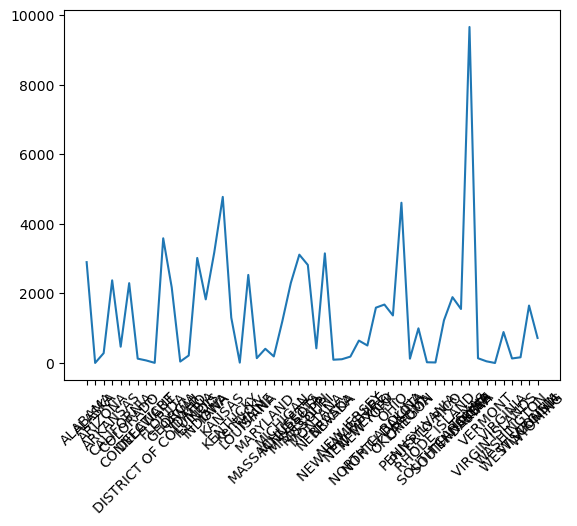

```python
plt.plot(state_tornado_totals['STATE'],state_tornado_totals['EVENT_TYPE'])
plt.xticks(rotation=45)
```

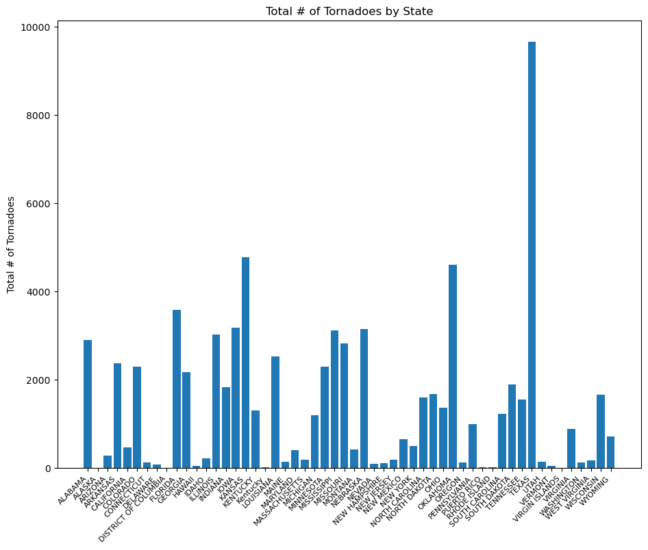

```python
plt.figure(figsize=(11,8.5))
plt.bar(state_tornado_totals['STATE'],height=state_tornado_totals['EVENT_TYPE'])
plt.xticks(rotation=45,ha='right',fontsize=8)
plt.ylabel('Total # of Tornadoes')
plt.title('Total # of Tornadoes by State')
```

### There is another python package specifically designed for plotting statistical analysis of a `pandas.DataFrame`

It is called `seaborn` (https://seaborn.pydata.org/) Try installing it and playing with it